# MAS8952 Assignment 1

### Libraries and Source Files

```r
options(echo=FALSE)
library(plotly)
library(reshape2)
library(ggplot2)
library(magrittr)
library(tidyverse)
library(gridExtra)
library(faraway)
library(matrixcalc)
library(devtools)
library(rdist)
library(animation)
library(knitr)
```

```r
source_url("https://raw.githubusercontent.com/TWBoughen/MAS8952/main/Assignment1/GP.R")
source_url("https://raw.githubusercontent.com/TWBoughen/MAS8952/main/Assignment1/means.R")
source_url("https://raw.githubusercontent.com/TWBoughen/MAS8952/main/Assignment1/kernels.R")
```

```
i SHA-1 hash of file is 26e75f040ba146b50f7a09004fe173aae4059155

i SHA-1 hash of file is 587530acdf700a27ef9a80e63bf9fc48949d7cbc

i SHA-1 hash of file is 596b9f55ba2f78967fb8e75091bc09c88895f5d8
```

### Other Useful Functions

```r
ones <- function(N) {
    return(rep(1, N))
}
```

### Part 1: Gaussian Process Regression

#### Task 1

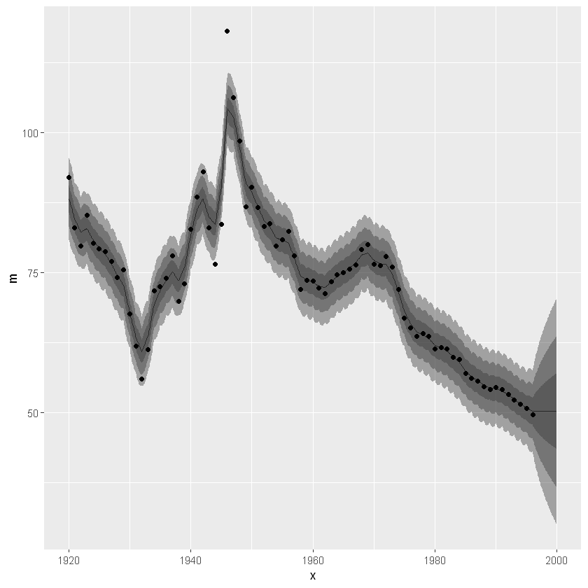

```r
X <- divusa$year
a <- divusa$marriage
N <- 1e3
X_star <- setdiff(seq(1920, 2000, length.out = N), X)
gp_ll_optim <- function(para) {
    return(gp_log_likelihood(X, a, constant_mean, exponential_kernel,
        error_var = para[1], amplitude = para[2], lengthscale = para[3], c = para[4]
    ))
}

ps <- optim(f = gp_ll_optim, par = c(5, 5, 1, 3), lower = c(9, 0, 0, 1), method = "L-BFGS-B", control = list(fnscale = -1))$par

Kxx <- exponential_kernel(X, X, amplitude = ps[2], lengthscale = ps[3])
Kxx.inv <- solve(Kxx)
c_hat <- t(ones(length(X))) %*% Kxx.inv %*% a / t(ones(length(X))) %*% Kxx.inv %*% ones(length(X))
post_out <- gp_posterior(X_star, X, a, constant_mean, brownian_kernel, error_var = ps[1], amplitude = 10, lengthscale = 8, c = c_hat)
postMean <- post_out$mean_vec
postVar <- post_out$cov_mat

x <- X_star[1:N - 1]
v <- diag(postVar)
m <- postMean
gp_dat <- data.frame(x, m, v)
plot_1_1 <- ggplot(data = gp_dat) +
    geom_line(aes(x = x, y = m)) +
    geom_ribbon(aes(x = x, ymin = (m - 1 * sqrt(v)), ymax = (m + 1 * sqrt(v))), alpha = 0.4) +
    geom_ribbon(aes(x = x, ymin = (m - 2 * sqrt(v)), ymax = (m + 2 * sqrt(v))), alpha = 0.4) +
    geom_ribbon(aes(x = x, ymin = (m - 3 * sqrt(v)), ymax = (m + 3 * sqrt(v))), alpha = 0.4) +
    geom_point(data = divusa, aes(x = year, y = marriage))
plot_1_1
```

#### Task 2

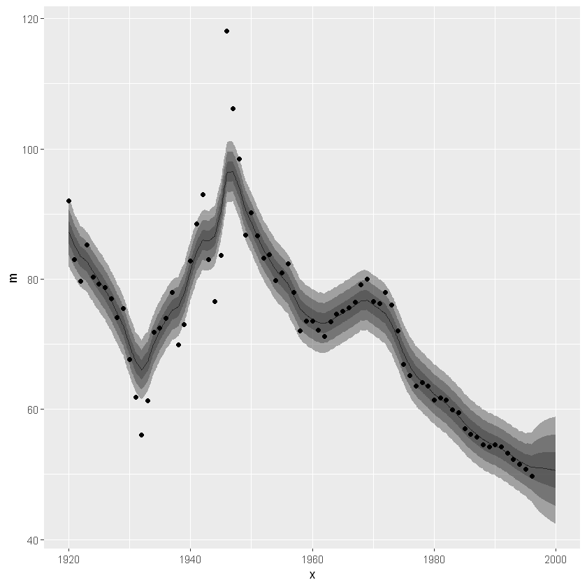

```r
X <- divusa$year
a <- divusa$marriage
N <- 1e3
X_star <- setdiff(seq(1920, 2000, length.out = N), X)
gp_ll_optim <- function(para) {
    return(gp_log_likelihood(X, a, linear_mean, exponential_kernel,
        error_var = para[1], amplitude = para[2], lengthscale = para[3], a = para[4], b = para[5]
    ))
}

ps <- optim(f = gp_ll_optim, par = c(9, 5, 5, -0.5, 1000), lower = c(9, 0, 0, -Inf, -Inf), method = "L-BFGS-B", control = list(fnscale = -1))$par

post_out <- gp_posterior(X_star, X, a, linear_mean, exponential_kernel,
    error_var = ps[1], amplitude = 10, lengthscale = ps[3], a = ps[4], b = ps[5]
)
postMean <- post_out$mean_vec
postVar <- post_out$cov_mat

x <- X_star[1:N - 1]
v <- diag(postVar)
m <- postMean
gp_dat <- data.frame(x, m, v)
plot_1_1 <- ggplot(data = gp_dat) +
    geom_line(aes(x = x, y = m)) +
    geom_ribbon(aes(x = x, ymin = (m - 1 * sqrt(v)), ymax = (m + 1 * sqrt(v))), alpha = 0.4) +
    geom_ribbon(aes(x = x, ymin = (m - 2 * sqrt(v)), ymax = (m + 2 * sqrt(v))), alpha = 0.4) +
    geom_ribbon(aes(x = x, ymin = (m - 3 * sqrt(v)), ymax = (m + 3 * sqrt(v))), alpha = 0.4) +
    geom_point(data = divusa, aes(x = year, y = marriage))
plot_1_1
```

#### Task 3

The two posterior GPs are extremely similar, with the only two noticable differences being smoother pointwise variances in the second posterior GP, and that the mean in second posterior GP continues to decrease slightly whereas the mean in the first posterior GP goes flat.

Both seem to fit the data quite well, but it seems hard to fit an appropriate GP to this data as it starts off volatile but becomes extremely smooth towards the end of the timeframe making picking a good kernel and hyperparameters hard.

Also there appears to be a significant drop in future uncertainty in the second posterior GP compared to the first posterior GP, probably due to the better choice of mean function, as all of the other hyperparameters and kernels are either the same or very similar.

### Part 2: Gaussian Processes in Higher Dimensions

#### Task 1

```r
constant_meanHD <- function(X, c = 0, ...) {
    return(0 * X + c)
}
```

#### Task 2

```r
sq_exp_kernelHD <- function(X, Y, lambda = 1, L = 1, ...) {
    return(lambda * exp(-cdist(X, Y)^2 / (2 * L)))
}
```

#### Task 3

```r
sqExpPerKer <- function(X, Y, A1 = 1, L1 = 1, A2 = 1,
                        L2 = 1, period = 1, ...) {
    return(squared_exponential_kernel(X[, 1], Y[, 1], amplitude = A1, lengthscale = L1) *
        periodic_kernel(X[, 2], Y[, 2],
            amplitude = A1,
            lengthscale = L2, period = period
        ))
}
```

#### Task 4

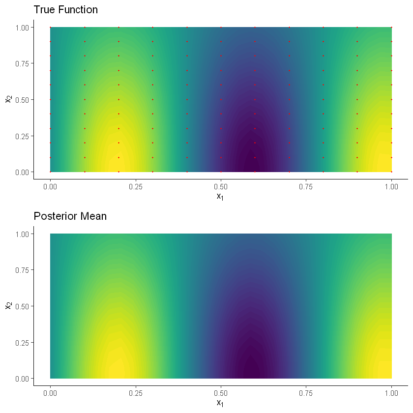

```r
func <- function(x_vec) {
    x1s <- x_vec[, 1]
    x2s <- x_vec[, 2]
    output <- 0.5 + sin(8 * x1s) * exp(-x2s^2)
    return(output)
}

x1_pred <- seq(0, 1, length.out = 30)
x2_pred <- seq(0, 1, length.out = 30)
x_pred <- as.matrix(expand.grid(x1_pred, x2_pred))
x1_cond <- seq(0, 1, by = 0.1)
x2_cond <- seq(0, 1, by = 0.1)
x_cond <- as.matrix(expand.grid(x1_cond, x2_cond))
y_cond <- func(x_cond)

posterior <- gp_posterior(x_pred, x_cond, y_cond, constant_meanHD, sq_exp_kernelHD, error_var = 0.01, c = 0.5, L = 0.1, lambda = 100)


func_evals <- t(matrix(func(x_pred), nrow = 30))
rownames(func_evals) <- x1_pred
colnames(func_evals) <- x2_pred

# true function dataframe
func_df <- as.data.frame(func_evals) %>%
    rownames_to_column(var = "row") %>%
    gather(col, value, -row) %>%
    mutate(
        row = as.numeric(row),
        col = as.numeric(col)
    )
# point dataframe
point_df <- data.frame(x = x_cond[, 1], y = x_cond[, 2])

func_plot <- ggplot(func_df, aes(x = col, y = row, z = value, color = after_stat(level))) +
    geom_contour_filled(bins = 80, show.legend = FALSE) +
    geom_point(data = point_df, aes(x = x, y = y), inherit.aes = FALSE, color = "red", size = 0.4) +
    theme_classic() +
    labs(x = expression(x[1]), y = expression(x[2])) +
    ggtitle("True Function")
####### Plot Posterior Mean

posterior_mean <- t(matrix(posterior$mean_vec, nrow = 30))[1:30, ]
rownames(posterior_mean) <- x1_pred
colnames(posterior_mean) <- x2_pred

# posterior mean dataframe
posterior_mean_df <- as.data.frame(posterior_mean) %>%
    rownames_to_column(var = "row") %>%
    gather(col, value, -row) %>%
    mutate(
        row = as.numeric(row),
        col = as.numeric(col)
    )
posterior_mean_plot <- ggplot(posterior_mean_df, aes(x = col, y = row, z = value, color = after_stat(level))) +
    geom_contour_filled(bins = 80, show.legend = FALSE) +
    theme_classic() +
    labs(x = expression(x[1]), y = expression(x[2])) +
    ggtitle("Posterior Mean")

####### Arrange the two plots together

grid.arrange(func_plot, posterior_mean_plot, ncol = 1)
```

For this task I have used a multidimensional adaptation of the squared exponential kernel, and chose the hyperparameters by tuning them manually until the plots looked similar, I chose the mean hyperparameter to be $\ c= 0.5$, based on the function we have been given  
<sub>Note: I have used 0.01 error variance as if it is zero the system approaches singular</sub>

#### Task 5

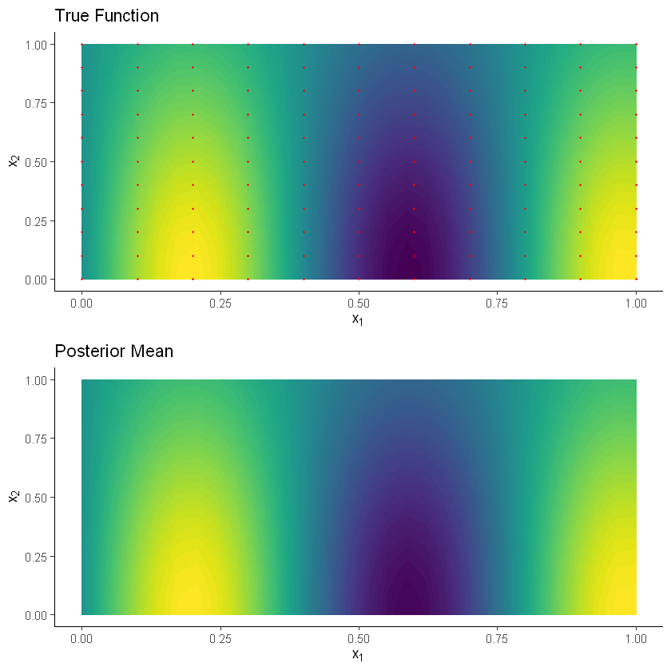

```r
func <- function(x_vec) {
    x1s <- x_vec[, 1]
    x2s <- x_vec[, 2]
    output <- 0.5 + sin(8 * x1s) * exp(-x2s^2)
    return(output)
}

x1_pred <- seq(0, 1, length.out = 30)
x2_pred <- seq(0, 1, length.out = 30)
x_pred <- as.matrix(expand.grid(x1_pred, x2_pred))
x1_cond <- seq(0, 1, by = 0.1)
x2_cond <- seq(0, 1, by = 0.1)
x_cond <- as.matrix(expand.grid(x1_cond, x2_cond))
y_cond <- func(x_cond)
posterior <- gp_posterior(x_pred, x_cond, y_cond, constant_meanHD, sqExpPerKer, error_var = 0.01, c = 1 / 2, A1 = 10, A2 = 10, L1 = 0.3, L2 = 5, period = 3)
func_evals <- t(matrix(func(x_pred), nrow = 30))
rownames(func_evals) <- x1_pred
colnames(func_evals) <- x2_pred
# true function dataframe
func_df <- as.data.frame(func_evals) %>%
    rownames_to_column(var = "row") %>%
    gather(col, value, -row) %>%
    mutate(
        row = as.numeric(row),
        col = as.numeric(col)
    )
# point dataframe
point_df <- data.frame(x = x_cond[, 1], y = x_cond[, 2])

func_plot <- ggplot(func_df, aes(x = col, y = row, z = value, color = after_stat(level))) +
    geom_contour_filled(bins = 80, show.legend = FALSE) +
    geom_point(data = point_df, aes(x = x, y = y), inherit.aes = FALSE, color = "red", size = 0.4) +
    theme_classic() +
    labs(x = expression(x[1]), y = expression(x[2])) +
    ggtitle("True Function")
####### Plot Posterior Mean

posterior_mean <- t(matrix(posterior$mean_vec, nrow = 30))[1:30, ]
rownames(posterior_mean) <- x1_pred
colnames(posterior_mean) <- x2_pred
# posterior mean dataframe
posterior_mean_df <- as.data.frame(posterior_mean) %>%
    rownames_to_column(var = "row") %>%
    gather(col, value, -row) %>%
    mutate(
        row = as.numeric(row),
        col = as.numeric(col)
    )
posterior_mean_plot <- ggplot(posterior_mean_df, aes(x = col, y = row, z = value, color = after_stat(level))) +
    geom_contour_filled(bins = 80, show.legend = FALSE) +
    theme_classic() +
    labs(x = expression(x[1]), y = expression(x[2])) +
    ggtitle("Posterior Mean")
grid.arrange(func_plot, posterior_mean_plot, ncol = 1)
```

For this task I have used a multidimensional product of a periodic and a squared exponential kernel as that seems plausible based on the function given. I also used a constant mean as that looks correct based on the function given. I chose the hyperparameter for the mean to be $\ c = 0.5$ purely based on the function given, as for the other hyperparameters I tweaked them until the plots looked similar enough.  
<sub>Note: I have used 0.01 error variance as if it is zero the system approaches singular</sub>

### Part 3: Bayesian Optimisation

#### Task 1

First note that: $$\ f(\underline{x})|\underline{f}_{X_n} = \underline{a}_n \sim \mathcal{N}(\tilde{m},\tilde{k})$$ $$\ f(\underline{x}) - a^{*}|\underline{f}_{X_n} = \underline{a}_n \sim \mathcal{N}(\tilde{m} - a^{*},\tilde{k}) $$ $$\ (f(\underline{X}) - a^*|\underline{f}_{X_n}) = \underline{a}_n = Z\sqrt{\tilde{k}(\underline{X},\underline{X}}) + (\tilde{m}(\underline{X}) - a^*)$$ Where, $\ Z \sim \mathcal{N}(0,1) $.

We want to calculate: $$\ \mathbb{E}[\text{max}(f(\underline{x}) - a^*,0)|\underline{f}_{X_n} = \underline{a}_n] $$ From now on, we will suppress the condtioning on $\ \underline{f}_{X_n} = \underline{a}_n$ $$\ = \mathbb{E}[f(\underline{x})-a^*|f(\underline{x})-a^* > 0]$$ $$\ = \mathbb{E}[Z\sqrt{\tilde{k}(\underline{x},\underline{x}}) + (\tilde{m}(\underline{x}) - a^*)|Z> d], \qquad \text{with } d = \frac{a^* - \tilde{m}(\underline{x})}{\sqrt{\tilde{k}(\underline{x},\underline{x}})}$$ $$\ = \sqrt{\tilde{k}(\underline{x},\underline{x}}) \mathbb{E}[Z|Z>d] + (\tilde{m}(\underline{x}) - a^*)\mathbb{E}[1|Z>d])$$ $$\ = \sqrt{\tilde{k}(\underline{x},\underline{x}})\int_{d}^{\infty}Z \phi(Z)\;dZ + (\tilde{m}(\underline{x}) - a^*)\int_{d}^{\infty} \phi(Z)\;dZ$$ Noticing that $\ Z\phi(Z) = -\phi^{'}(Z)$, $$\ = \sqrt{\tilde{k}(\underline{x},\underline{x}}) \phi(d) + (\tilde{m}(\underline{x}) - a^*)(1-\Phi(d))$$ $$\ = \sqrt{\tilde{k}(\underline{x},\underline{x}}) \phi(-d) + (\tilde{m}(\underline{x}) - a^*)\Phi(-d)$$ $$\ = \sqrt{\tilde{k}(\underline{x},\underline{x}}) \phi \left(\frac{\tilde{m}(\underline{x}) - a^*}{\sqrt{\tilde{k}(\underline{x},\underline{x}})} \right) + (\tilde{m}(\underline{x}) - a^*)\Phi \left(\frac{\tilde{m}(\underline{x}) - a^*}{\sqrt{\tilde{k}(\underline{x},\underline{x}})} \right)$$

#### Task 2

```r
expected_improvement <- function(x, x_cond, y_cond, mean_func, kernel_func, ...) {
    posterior <- gp_posterior(x, x_cond, y_cond, mean_func, kernel_func, ...)
    m_tilde <- posterior$mean_vec
    a_star <- max(y_cond)
    k_tilde <- posterior$cov_mat
    inside <- (m_tilde - a_star) / (sqrt(diag(k_tilde)))

    EI <- sqrt(diag(k_tilde)) * dnorm(inside) + (m_tilde - a_star) * pnorm(inside)
    return(list("EI" = EI, "post_mean" = m_tilde, "post_k" = k_tilde))
}
```

#### Task 3

```r
f <- function(x) {
    out <- -sin(3 * x) - x^2 + 0.7 * x
    return(out)
}

x_1 <- c(-0.9, 1)
a_1 <- f(x_1)
N <- 10
EI_plots <- list()
post_plots <- list()
pb <- txtProgressBar(min = 0, max = N, initial = 0, style = 3)

for (n in 1:N) {
    x_vals <- seq(-1, 2, by = 0.01)
    calc <- expected_improvement(x_vals, x_1, a_1, constant_mean, squared_exponential_kernel, lengthscale = 0.5, amplitude = 1, c = 0, error_var = 0.01)
    exp_improve <- calc$EI

    EI_df <- data.frame(x = x_vals, EI = exp_improve)
    EI_plots[[n]] <- ggplot(data = EI_df, aes(x = x, y = EI)) +
        geom_line() +
        scale_x_continuous(limits = c(-1, 2)) +
        theme_bw()

    func_df <- data.frame(x = x_vals, y = f(x_vals))
    post_mean <- calc$post_mean
    post_k <- calc$post_k
    post_samples <- rmvn_svd(100, post_mean, post_k)
    gp_samples_df <- melt(data.frame(x_vals, t(post_samples)), id = "x_vals")
    point_df <- data.frame(x = x_1, y = a_1, alpha = rep(0.1, length(x_1)) + 0.9 * seq(1, length(x_1)) / length(x_1))
    objective_evals <- f(x_vals)
    objective_df <- data.frame(x = x_vals, y = objective_evals)
    post_df <- data.frame(x = x_vals, o = diag(post_k), y = post_mean)
    gp_sample_plot <- ggplot(gp_samples_df) +
        geom_line(data = objective_df, aes(x = x, y = y), color = "blue") +
        geom_line(aes(x = x_vals, y = value, group = variable), color = "#86e4fb", alpha = 0.1, show.legend = FALSE) +
        geom_point(data = point_df, aes(x = x, y = y), alpha = point_df$alpha) +
        geom_ribbon(data = post_df, aes(x = x, ymin = y - 1.96 * sqrt(o), ymax = y + 1.96 * sqrt(o)), alpha = 0) +
        theme_bw() +
        labs(x = "", y = "f(x)") +
        ggtitle(paste("Posterior Gaussian Process, n = ", n)) +
        scale_x_continuous(limits = c(-1, 2)) +
        scale_y_continuous(limits = c(-3, 3))
    post_plots[[n]] <- gp_sample_plot
    x_1 <- c(x_1, x_vals[exp_improve == max(exp_improve, na.rm = T)])
    a_1 <- f(x_1)
    setTxtProgressBar(pb, n)
}
```

The individual plots can be accessed like below:

```r
# post_plots[[n]]  Plot of the posterior gaussian process at step n
# EI_plots[[n]]    Plot of the expected improvement at step n
```

This code may not run as it requires a library! All it does is create a gif of the 10 plots

```r
## Outputting plots as a GIF
pb <- txtProgressBar(min = 0, max = N, initial = 0, style = 3)
saveGIF(
    {
        for (i in 1:N) {
            setTxtProgressBar(pb, i)
            grid.arrange(post_plots[[i]], EI_plots[[i]])
        }
    },
    interval = 0.5,
    movie.name = "part_3_task_3.gif"
)
```

[figure not shown]

### Part 4: Bayesian Cubature

#### Task 1

Note that the integral has the following properties: $$\ \int_{A}\lambda f(\underline{x})\;d{\underline{x}} = \lambda \int_{A} f(\underline{x})\;d{\underline{x}}, \quad \text{and}$$ $$\ \int_{A}f(\underline{x}) + g(\underline{x})\;d{\underline{x}} = \int_{A}f(\underline{x})\;d{\underline{x}} +\int_{A}g(\underline{x})\;d{\underline{x}} $$ Thus, $\ I(\cdot)$ is a linear operator.

#### Task 2

Since $\ I(\cdot)$ is a continuous and linear , $\ If$ is also a gaussian process that is entirely defined by its mean vector and covariance matrix which we calculate below: $$\ \mathbb{E}\left[If(\underline{x})\right] = \mathbb{E}\left[ \int_{A} f(\underline{x})\;d{\underline{x}}\right]=\int_{A}\mathbb{E}\left[f(\underline{x})\right]\;d\underline{x} =\int_{A}m(\underline{x})\;d\underline{x} $$ $$\ \text{Cov}(If(\underline{x}),If(\underline{y}) ) = \text{Cov}\left(\int_{A} f(\underline{x})\;d{\underline{x}},\int_{A} f(\underline{y})\;d{\underline{y}} \right) = \int_{A} \int_{A}\text{Cov}(f(\underline{x}),f(\underline{y}))\;d\underline{x}d\underline{y} = \int_{A} \int_{A} k(\underline{x},\underline{y})\;d\underline{x}d\underline{y}$$

#### Task 3

We know the posterior distribution of a gaussian process is also a gaussian process with mean and covariance as below: $$\ \mathbb{E}\left[f(\underline{x})|\underline{f}_X = \underline{a}\right] = m(\underline{x}) + K_X(\underline{x})^T K_{XX}^{-1}(\underline{a} -\underline{m}_X)$$ $$\ \tilde{k}(\underline{x},\underline{y}) = k(\underline{x},\underline{y}) +K_X(\underline{x})^T K_{XX}^{-1}K_X(\underline{y}) $$ Applying $\ I $ to these gives: $$\ \tilde{\mu}= \mathbb{E}\left[If(\underline{x})|\underline{f}_X = \underline{a}\right] = \int_{A} m(\underline{x}) + K_X(\underline{x})^T K_{XX}^{-1}(\underline{a} -\underline{m}_X) \;d\underline{x} $$ $$\ = \int_{A}m(\underline{x})\;d\underline{x} + \int_{A}K_X(\underline{x})^T K_{XX}^{-1}(\underline{a} -\underline{m}_X)\;d\underline{x}$$ $$\ = \int_{A}m(\underline{x})\;d\underline{x} + \int_{A}K_X(\underline{x})^T\;d\underline{x}\;K_{XX}^{-1}(\underline{a} -\underline{m}_X)$$ $$\ = \int_{A}m(\underline{x})\;d\underline{x} + \left[\int_{A}K_X(\underline{x})\;d\underline{x}\right]^T\;K_{XX}^{-1}(\underline{a} -\underline{m}_X)$$ and,

$$\ \tilde{\sigma ^2} = \text{Cov}(f(\underline{x}),f(\underline{y})\;|\underline{f}_X = \underline{a}) = \int_{A}\int_{A} k(\underline{x},\underline{y}) +K_X(\underline{x})^T K_{XX}^{-1}K_X(\underline{y}) \;d\underline{x}\;d\underline{y}$$$$\ = \int_A\int_A k(\underline{x},\underline{y}) \;d\underline{x}\;d\underline{y} + \int_A\int_A K_X(\underline{x})^T K_{XX}^{-1}K_X(\underline{y}) \;d\underline{x}\;d\underline{y}$$$$\ = \int_A\int_A k(\underline{x},\underline{y}) \;d\underline{x}\;d\underline{y} + \int_A K_X(\underline{x})^T\;d\underline{x}\;K_{XX}^{-1}\int_A K_X(\underline{y})\;d\underline{y}$$$$\ = \int_A\int_A k(\underline{x},\underline{y}) \;d\underline{x}\;d\underline{y} + \left[\int_A K_X(\underline{x})\;d\underline{x}\right]^T\;K_{XX}^{-1}\left[\int_A K_X(\underline{y})\;d\underline{y}\right].$$

#### Task 4

Let $\ f \sim \mathcal{GP}(m,k)$, where $\ m(x) = c$ and $$\ k(x,y) = \lambda^2\left(1+\nu|x-y|\right)\text{exp}(-\nu|x-y|)$$ with $\ \nu = \frac{\sqrt{3}}{\ell}.\\$
$\ k $ can also be written as: $$\ k(x,y) = \left\{ \begin{array}{ll} \lambda^2 (1 - \nu(x-y))\text{exp}(\nu (x-y)) & 0 < x \leq y \\ \lambda^2 (1 + \nu(x-y))\text{exp}(-\nu (x-y)) & y < x < 1 \\ \end{array} \right. $$ If we want to integrate $\ k(x,y)$ over $\ x \in (0,1) $ we can simply do it piece-wise: $$\ \int_0^1 k(x,y) \;dxdy = \int_0^y\lambda^2 (1 - \nu(x-y))\text{exp}(\nu (x-y))\;dx + \int_y^1 \lambda^2(1 + \nu(x-y))\text{exp}(-\nu (x-y))\;dx $$ Calculating the first integral using integration by parts: $$\ \begin{array}{ll} u = 1-\nu(x-y)& u' = -\nu \\ v' = \text{exp}(\nu (x-y)) & v = \nu^{-1} \cdot \text{exp}(\nu (x-y)) \end{array} $$ $$\ \int_0^y\lambda^2 (1 - \nu(x-y))\text{exp}(\nu (x-y))\;dx = \lambda^2\left[\nu^{-1}(1 - \nu(x-y))\text{exp}(\nu (x-y)) + \nu^{-1}\text{exp}(\nu (x-y))\right]_0^y$$ $$\ = \lambda^2\left[2\nu^{-1} - \text{exp}(-\nu y)(y + 2\nu^{-1})\right] $$ Similarly for the second integral: $$\ \begin{array}{ll} u = 1+\nu(x-y)& u' = \nu \\ v' = \text{exp}(-\nu (x-y)) & v = -\nu^{-1} \cdot \text{exp}(-\nu (x-y)) \end{array} $$ $$\ \int_y^1 \lambda^2(1 + \nu(x-y))\text{exp}(-\nu (x-y))\;dx = \lambda^2\left[-\nu^{-1}(1 + \nu(x-y))\text{exp}(-\nu (x-y)) - \nu^{-1}\text{exp}(-\nu (x-y)) \right]_y^1$$ $$\ = \lambda^2\left\{2\nu^{-1} + \text{exp}(-\nu(1-y))(y - 1 - 2\nu^{-1})\right\} $$ Summing these results gives: $$\ \int_0^1 k(x,y) \;dxdy = \lambda^2 \left\{ 4\nu^{-1} + \text{exp}(-\nu(1-y))(y - 1 - 2\nu^{-1}) - \text{exp}(-\nu y)(y + 2\nu^{-1}) \right\}$$ Subbing in the value of $\ \nu$: $$\ \int_0^1 k(x,y) \;dxdy = \lambda^2 \left\{ \frac{4\ell}{\sqrt{3}} + \text{exp}\left(-\frac{\sqrt{3}}{\ell}(1-y)\right)\left(y - 1 - \frac{2\ell}{\sqrt{3}}\right) - \text{exp}\left(-\frac{\sqrt{3}}{\ell}y\right)\left(y + \frac{2\ell}{\sqrt{3}}\right) \right\}. $$
We can now integrate out $\ y$: $$\ \int_0^1 \int_0^1 k(x,y) \;dxdy = \int_0^1 \lambda^2 \left\{ \frac{4\ell}{\sqrt{3}} + \text{exp}\left(-\frac{\sqrt{3}}{\ell}(1-y)\right)\left(y - 1 - \frac{2\ell}{\sqrt{3}}\right) - \text{exp}\left(-\frac{\sqrt{3}}{\ell}y\right)\left(y + \frac{2\ell}{\sqrt{3}}\right) \right\}\;dy $$ $$\ =\lambda^2\left[ \frac{4\ell}{\sqrt{3}}y+ \frac{\ell}{\sqrt{3}}\text{exp}\left(-\frac{\sqrt{3}}{\ell}(1-y)\right)\left( y - 1 - \frac{3\ell}{\sqrt{3}}\right)+ \frac{\ell}{\sqrt{3}}\text{exp}\left(\frac{-\sqrt{3}}{\ell}y\right)\left(y + \frac{3\ell}{\sqrt{3}}\right) \right]_0^1 $$

$$\ = \frac{\lambda^2 \ell}{\sqrt{3}}\left[ 4y+ \text{exp}\left(-\frac{\sqrt{3}}{\ell}(1-y)\right)\left( y - 1 - \frac{3\ell}{\sqrt{3}}\right)+ \text{exp}\left(\frac{-\sqrt{3}}{\ell}y\right)\left(y + \frac{3\ell}{\sqrt{3}}\right) \right]_0^1 $$$$\ = \frac{\lambda^2\ell}{\sqrt{3}}\left\{ 4 - \frac{3\ell}{\sqrt{3}} + \text{exp}\left(-\frac{\sqrt{3}}{\ell}\right)\left(1 + \frac{3\ell}{\sqrt{3}}\right) - \frac{3\ell}{\sqrt{3}} - \text{exp}\left(-\frac{\sqrt{3}}{\ell}\right)\left(-1 -\frac{3\ell}{\sqrt{3}}\right) \right\} $$$$\ = \frac{\lambda^2\ell}{\sqrt{3}}\left\{ 4 - \frac{6\ell}{\sqrt{3}} + \text{exp}\left(-\frac{\sqrt{3}}{\ell}\right)\left(2 + \frac{6\ell}{\sqrt{3}}\right) \right\} $$

Now, integrating the mean: $$\ \int_0^1m(x)\;dx = \int_0^1 c \;dx = \left[cx\right]_0^1 = c $$

#### Task 5

```r
# integrand function
integrand <- function(x) {
    return(0.5 + sin(8 * x) * exp(-x**2))
}
# prior kernerl
kernel_prior <- function(x, y, lambda_sq = 1, L = 1) {
    out1 <- lamba_sq * (1 + sqrt(3) * abs(x - y) / L)
    out2 <- exp(-sqrt(3) * abs(x - y) / L)
    return(lambda_sq * out1 * out2)
}
kernel_posterior <- function(lambda_sq =1, L = 1) {
    out = exp(-sqrt(3)/L)*(2+6*L/sqrt(3)) - 6*L/sqrt(3) + 4
    return(lambda_sq*L*out/sqrt(3))
}
mean_prior = constant_mean
```

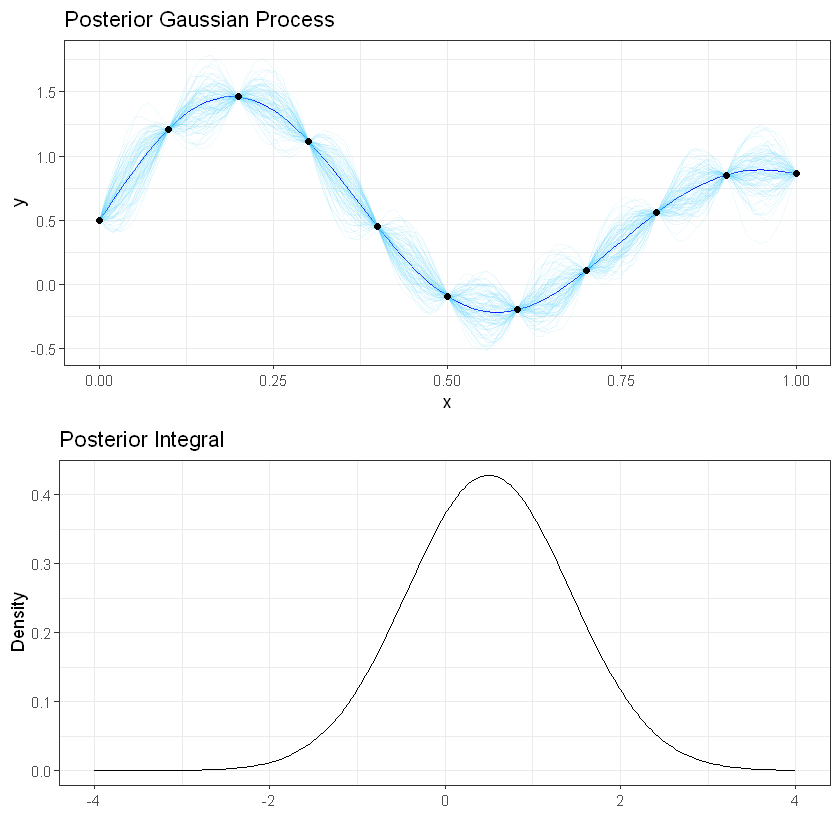

```r
c = 0.5
lambda_sq = 1
L = 1


x_cond = seq(0, 1, length.out = 11)
y_cond = integrand(x_cond)
x_pred = seq(0, 1, length.out = 100)
posterior_samples = gp_posterior_sample(100, x_pred, x_cond, y_cond, constant_mean, matern_32_kernel, amplitude=10, lengthscale=0.5)

gp_samples_df = melt(data.frame(x_pred, t(posterior_samples)), id = "x_pred") # turn into a dataframe
point_df = data.frame(x = x_cond, y = y_cond)

integrand_evals = integrand(x_pred)
integrand_df = data.frame(x = x_pred, y = integrand_evals)

gp_sample_plot = ggplot(gp_samples_df) +
                geom_line(data = integrand_df, aes(x = x, y = y), color='blue') +
                geom_line(aes(x = x_pred, y = value, group = variable), color='#48cdf9', alpha=0.1, show.legend = FALSE) +
                geom_point(data = point_df, aes(x = x, y = y)) +
                theme_bw() + labs(x = "x", y = "y") +
                ggtitle("Posterior Gaussian Process")

integral_mean = c
integral_variance = kernel_posterior(lambda_sq=lambda_sq,L=L)

eval_grid = seq(-4, 4, length.out = 200) # grid of points used in evaluating the pdf of the posterior integral
posterior_integral_pdf = dnorm(eval_grid, mean=integral_mean, sd=sqrt(integral_variance))

integral_df = data.frame(x = eval_grid, y = posterior_integral_pdf)

integral_plot = ggplot(data = integral_df, aes(x = x, y = y)) + geom_line() + theme_bw() +
                labs(x = "", y = "Density") + ggtitle("Posterior Integral")


####### Arrange two plots together

grid.arrange(gp_sample_plot, integral_plot, ncol = 1)
```